# Examples of map layers

# mapquest-sat

`plotRGB(openmap(x,path="mapquest-sat"))`

Tiles courtesy of [MapQuest](http://www.mapquest.com), portions courtesy NASA/JPL-Caltech and U.S. Depart. of Agriculture, Farm Service Agency.

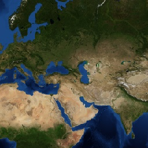

[figure not shown]

[figure not shown]

# mapquest-labels

`plotRGB(openmap(x,path="mapquest-labels"))`

Tiles courtesy of [MapQuest](http://www.mapquest.com). Data by [OpenStreetMap](http://openstreetmap.org), available under the [Open Database License](http://opendatacommons.org/licenses/odbl)

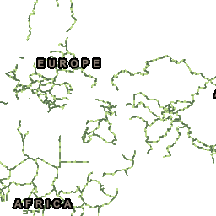

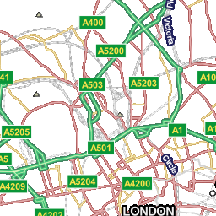

[figure not shown]

# osm-cyclemap

`plot(openmap(x,path="osm-cyclemap"))`

© [OpenStreetMap](http://openstreetmap.org/copyright) contributors. Data by [OpenStreetMap](http://openstreetmap.org), available under the [Open Database License](http://opendatacommons.org/licenses/odbl), cartography is licensed as [CC BY-SA](http://creativecommons.org/licenses/by-sa/2.0).

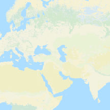

[figure not shown]

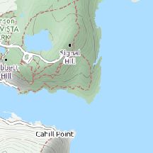

# osm-seamap

`plotRGB(openmap(x,path="osm-seamap"))`

© [OpenStreetMap](http://openstreetmap.org/copyright) contributors. Data by [OpenStreetMap](http://openstreetmap.org), available under the [Open Database License](http://opendatacommons.org/licenses/odbl), cartography is licensed as [CC BY-SA](http://creativecommons.org/licenses/by-sa/2.0).

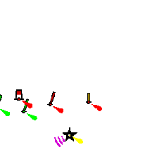

# osm-fr

`plot(openmap(x,path="osm-fr"))`

© [OpenStreetMap](http://openstreetmap.org/copyright) contributors. Data by [OpenStreetMap](http://openstreetmap.org), available under the [Open Database License](http://opendatacommons.org/licenses/odbl), cartography is licensed as [CC BY-SA](http://creativecommons.org/licenses/by-sa/2.0).

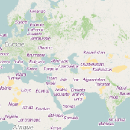

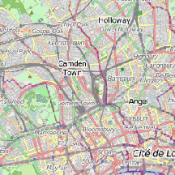

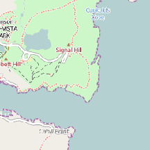

# landscape

`plot(openmap(x,path="landscape"))`

© [OpenStreetMap](http://openstreetmap.org/copyright) contributors. Data by [OpenStreetMap](http://openstreetmap.org), available under the [Open Database License](http://opendatacommons.org/licenses/odbl), cartography by [Thunderforest](http://www.thunderforest.com/)

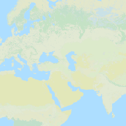

[figure not shown]

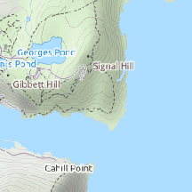

# hyda

`plot(openmap(x,path="hyda"))`

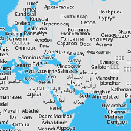

[figure not shown]

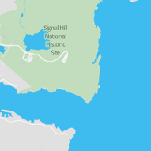

# hyda-base

`plot(openmap(x,path="hyda-base"))`

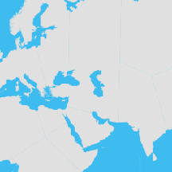

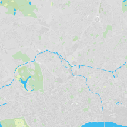

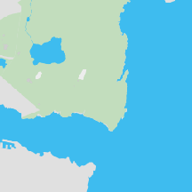

# hyda-roads

`plot(openmap(x,path="hyda-roads"))`

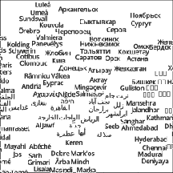

[figure not shown]

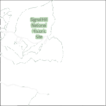

# opentopomap

`plot(openmap(x,path="opentopomap"))`

© [OpenStreetMap](http://openstreetmap.org/copyright) contributors. Data by [OpenStreetMap](http://openstreetmap.org), available under the [Open Database License](http://opendatacommons.org/licenses/odbl), cartography is licensed as [CC BY-SA](http://creativecommons.org/licenses/by-sa/2.0).

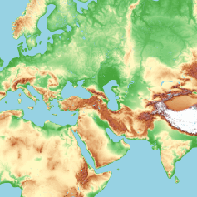

[figure not shown]

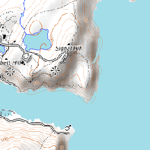

# maptoolkit

`plot(openmap(x,path="maptoolkit"))`

© [Toursprung GmbH](http://www.toursprung.com) Data by [OpenStreetMap](http://openstreetmap.org), available under the [Open Database License](http://opendatacommons.org/licenses/odbl)

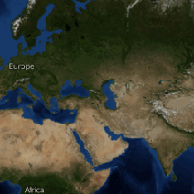

[figure not shown]

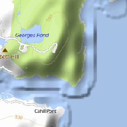

# waze

`plotRGB(openmap(x,path="waze"))`

© [Waze mobile](http://www.waze.com/legal/notices)

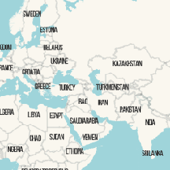

[figure not shown]

# humanitarian

`plot(openmap(x,path="humanitarian"))`

© [OpenStreetMap](http://openstreetmap.org/copyright) contributors. Data by [OpenStreetMap](http://openstreetmap.org), available under the [Open Database License](http://opendatacommons.org/licenses/odbl), cartography by [Humanitarian OSM team](http://hot.openstreetmap.org/about) is licensed as [CC BY-SA](http://creativecommons.org/licenses/by-sa/2.0).

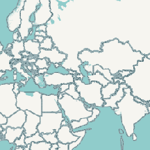

[figure not shown]

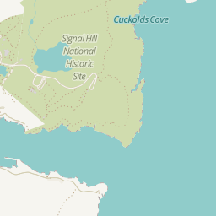

# cartodb

`plot(openmap(x,path="cartodb"))`

Map tiles by [CartoDB](http://cartodb.com) under [CC BY 3.0](http://creativecommons.org/licenses/by/3.0). Data by [OpenStreetMap](http://openstreetmap.org), available under the [Open Database License](http://opendatacommons.org/licenses/odbl)

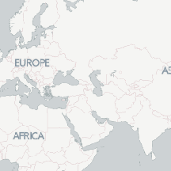

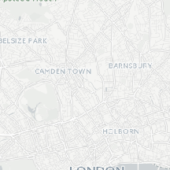

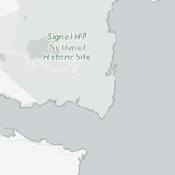

# cartodb-dark

`plot(openmap(x,path="cartodb-dark"))`

Map tiles by [CartoDB](http://cartodb.com) under [CC BY 3.0](http://creativecommons.org/licenses/by/3.0). Data by [OpenStreetMap](http://openstreetmap.org), available under the [Open Database License](http://opendatacommons.org/licenses/odbl)

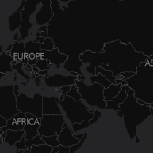

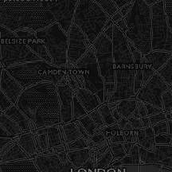

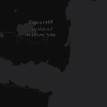

# historical

`plot(openmap(x,path="historical"))`

© [OpenStreetMap](http://openstreetmap.org/copyright) contributors. Data by [OpenStreetMap](http://openstreetmap.org), available under the [Open Database License](http://opendatacommons.org/licenses/odbl), cartography is licensed as [CC BY-SA](http://creativecommons.org/licenses/by-sa/2.0).

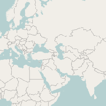

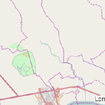

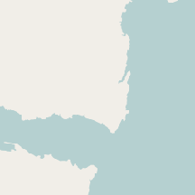